# SLR BUI 1 Tier 3 Report - Walleye

### Model Summary by Region

**AOC**: There is a statistically significant relationship between fish length and contaminant concentration. The power model used was: concentration = 0.000178 × Length<sup>2.01</sup> (R² = 0.807, p = < 0.001).

**Reference**: There is a statistically significant relationship between fish length and contaminant concentration. The power model used was: concentration = 2.06e-05 × Length<sup>2.412</sup> (R² = 0.718, p = < 0.001).

(#tab:virtual-advisory-table) Virtual advisory levels for Mercury in Walleye across regions. Values represent meals/month recommendations. Red cells indicate restrictive virtual advisory falling below the desired consumption rate of 8 meals/month; green cells indicate unrestrictive virtual advisory equal to or above the desired consumption rate.

```r
predictions_binned <- virtual_advisory$predictions %>%
  mutate(
    length_bin = cut(
      Length,
      breaks = c(seq(15, 75, by = 5), Inf),
      labels = c(paste(seq(15, 70, by = 5), seq(20, 75, by = 5), sep = "-"), "75+"),
      right = FALSE
    )
  ) %>%
  filter(!is.na(length_bin)) %>%
  group_by(region, length_bin) %>%
  summarise(
    mean_conc = mean(predicted, na.rm = TRUE),
    .groups = "drop"
  ) %>%
  mutate(
  meals_general   = assign_advisory(mean_conc, "General", params$contaminant),
  meals_sensitive = assign_advisory(mean_conc, "Sensitive", params$contaminant)
)





color_advisory_cell <- function(value, threshold = params$restrict_threshold) {
  if (is.na(value)) return("")
  if (value < threshold) {
    return(list(background = "red", color = "white", fontWeight = "bold"))
  } else {
    return(list(background = "forestgreen", color = "black", fontWeight = "bold"))
  }
}



virtual_long <- predictions_binned %>%
  pivot_longer(cols = c(meals_general, meals_sensitive),
               names_to = "Population",
               names_prefix = "meals_",
               values_to = "Advisory") %>%
  mutate(
    Population = case_when(
      Population == "general" ~ "General",
      Population == "sensitive" ~ "Sensitive"
    )
  )%>%
  filter(
    toupper(params$contaminant) == "MERCURY" | Population == "General"
  )


virtual_wide <- virtual_long %>%
  select(Region = region, Population, length_bin, Advisory) %>%
  pivot_wider(names_from = length_bin, values_from = Advisory)


virtual_adv_table <- reactable(
  virtual_wide,
  bordered = TRUE,
  highlight = TRUE,
  striped = TRUE,
  defaultColDef = colDef(
    style = function(value) {
      if (is.numeric(value) && !is.na(value)) {
        color_advisory_cell(value)
      } else {
        NULL
      }
    },
    align = "center"
  ),
  columns = list(
    Region = colDef(name = "Region", sticky = "left", style = list(fontWeight = "bold")),
    Population = colDef(name = "Population", sticky = "left", style = list(fontWeight = "bold"))
  )
)


virtual_adv_table
```

| Region | Population | 15-20 | 20-25 | 25-30 | 30-35 | 35-40 | 40-45 | 45-50 | 50-55 | 55-60 | 60-65 | 65-70 | 70-75 | 75+ |
| --- | --- | --- | --- | --- | --- | --- | --- | --- | --- | --- | --- | --- | --- | --- |
| AOC | General | 32 | 32 | 32 | 16 | 16 | 12 | 8 | 8 | 4 | 4 | 4 | 4 | 4 |
| AOC | Sensitive | 32 | 16 | 12 | 8 | 4 | 4 | 4 | 0 | 0 | 0 | 0 | 0 | 0 |
| Reference | General | 32 | 32 | 32 | 32 | 32 | 16 | 16 | 16 | 12 | 8 | 8 | 4 | 4 |
| Reference | Sensitive | 32 | 32 | 32 | 16 | 12 | 8 | 8 | 4 | 4 | 4 | 0 | 0 | 0 |

```r
# Decision making


# Step 3: Is AOC more restrictive than reference? Split AOC and reference tables
aoc_advisories <- virtual_long %>%
  filter(region == "AOC") %>%
  select(length_bin, Population, Advisory) %>%
  rename(AOC_Advisory = Advisory)

reference_advisories <- virtual_long %>%
  filter(region != "AOC") %>%
  group_by(length_bin, Population) %>%
  summarise(Ref_Advisory = median(Advisory, na.rm = TRUE), .groups = "drop")  # Median across references - important if >1 reference group


# Join and evaluate
tier3a_joined <- aoc_advisories %>%
  left_join(reference_advisories, by = c("length_bin", "Population")) %>%
  mutate(
    restrict_pass = AOC_Advisory >= params$restrict_threshold,
    restrict_fail = !restrict_pass,
    more_restrictive_than_ref = AOC_Advisory < Ref_Advisory,
    final_decision = case_when(
      restrict_pass ~ "Pass",
      restrict_fail & !more_restrictive_than_ref ~ "Pass",
      restrict_fail & more_restrictive_than_ref ~ "Fail",
      TRUE ~ "Unknown"
    )
  )


tier3a_summary <- tier3a_joined %>%
  group_by(Population) %>%
  summarise(
    n_bins = n(),
    n_below_thresh = sum(restrict_fail),
    n_below_ref = sum(restrict_fail & more_restrictive_than_ref),
    n_pass = n_bins - n_below_ref,
    pct_pass = round(100 * n_pass / n_bins, 1),
    .groups = "drop"
  ) %>%
  mutate(
    decision = if_else(n_below_ref == 0, "Pass", "Fail")
  )



tier3a_text <- tier3a_summary %>%
  mutate(
    summary = glue::glue(
      "**{Population}** population: Of {n_bins} size bins, {n_below_thresh} were below the desired consumption rate of {params$restrict_threshold} meals/month. ",
      "Of these, {n_below_ref} were more restrictive than reference."
    )
  ) %>%
  pull(summary) %>%
  glue::glue_collapse(sep = " ")

tier3a_overall <- if (any(tier3a_summary$decision == "Fail")) "Unsupportive" else "Supportive"


tier3a_summary_tibble <- tibble(
  Tier = "Tier 3A",
  Description = "Virtual Advisory",
  Metric = glue_collapse(glue("{tier3a_summary$Population}: {tier3a_summary$n_below_ref}/{tier3a_summary$n_bins} size bins restrictive or more restrictive than reference"), sep = "; "),
  Outcome = tier3a_overall
)
```

```r
cat(tier3a_text)
```

**General** population: Of 13 size bins, 5 were below the desired consumption rate of 8 meals/month. Of these, 3 were more restrictive than reference. **Sensitive** population: Of 13 size bins, 9 were below the desired consumption rate of 8 meals/month. Of these, 6 were more restrictive than reference.

**Tier 3A Overall Decision:** Unsupportive

## Tier 3B: Comparison of contaminant concentrations in Walleye in AOC to reference

To assess differences in fish contamination between the AOC and reference sites, contaminant–length relationships were modeled using Generalized Additive Models (GAMs), allowing for non-linear associations. For each priority contaminant and indicator species, we first tested whether the shape of the concentration–length relationship differed significantly between AOC and reference fish. Where models supported statistically similar trends (non-significant interaction), we compared size-adjusted contaminant levels using estimated marginal means. Where shapes differed significantly, contaminant concentration values were compared by GAM-predicted values at standardized lengths (e.g., 45cm) commonly consumed for each fish species. A threshold of α = 0.05 was used to evaluate statistical significance throughout.

(ref:Tier-3B-Figure) Mercury concentration in Walleye by length in the AOC compared to reference sites. Points are observed contaminant values, curves represent GAM model fit (with random effects dropped for simplicity, fitted across the 1st to 99th percentile of data to ensure reasonable support), ribbons represent 95% confidence interval.

```r
# Run this chunk to evaluate GAMs

gam.check(gam_model)

par(mar=c(3,3,3,0),mfrow=c(1,2))
acf(resid(gam_model), lag.max = 36, main = "ACF")
pacf(resid(gam_model), lag.max = 36, main = "pACF")

plot(gam_model)

summary(gam_model)


gam_valid = validate_gam(gam_model, data = gam_df)




knitr::kable(
  gam_valid %>%
    transmute(
      family, link, n, r2 = round(r2, 3),
      dev_expl = round(dev_expl, 3),
      acf_flag, pacf_flag, lb_flag,
      concurvity_max = round(concurvity_max, 3), concurvity_flag
    ),
  caption = "GAM validation summary"
)

# Expand the per-term tables when needed (e.g., in collapsible sections)
smooth_terms   <- gam_valid$smooth_table[[1]]
param_terms    <- gam_valid$param_table[[1]]
k_diagnostics  <- gam_valid$k_table[[1]]
lb_diagnostics <- gam_valid$lb_table[[1]]

# Example: flag text you can drop into the report
issue_msgs <- c(
  if (gam_valid$acf_flag)  "Residual ACF shows significant autocorrelation." else NULL,
  if (gam_valid$lb_flag)   "Ljung–Box test indicates autocorrelation at some lags." else NULL,
  if (any(k_diagnostics$k_flag, na.rm = TRUE)) "Some smooths suggest k may be too low (k-index < 1)." else NULL,
  if (gam_valid$concurvity_flag) "High concurvity detected (> 0.90). Consider simplifying terms." else NULL
)
if (length(issue_msgs) == 0) issue_msgs <- "No major validation flags detected."
cat(paste0("**Validation notes:** ", paste(issue_msgs, collapse = " ")))


concurvity(gam_model, full = T)


region_levels <- levels(model.frame(gam_model)$region)
exclude_re <- names(gam_model$smooth)[sapply(gam_model$smooth, function(s) s$bs == "re")]
```

(#tab:tier-3b-summary-table) Predicted Mercury concentrations (µg/g) in Walleye, estimated using generalized additive models (GAMs) across the observed range of fish lengths where data is available for both groups. Values represent model-predicted means with 95% confidence intervals. Asterisks (*) indicate size classes where the AOC differs significantly (p < 0.05) from reference.

[output not shown]

[output not shown]

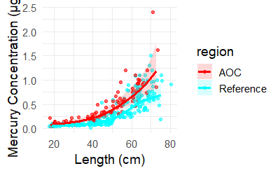

```r
lpmatrix_contrasts <- function(gam_model, length_seq, recent_data,
                               aoc_name = "AOC") {
  mf   <- model.frame(gam_model)
  regs <- levels(mf$region)
  refs <- setdiff(regs, aoc_name)
  stopifnot(length(refs) > 0)

  # Prediction grid (region × chosen lengths) + placeholders for RE factors
  newgrid <- expand.grid(region = regs, Length = length_seq, KEEP.OUT.ATTRS = FALSE)
  newgrid$region <- factor(newgrid$region, levels = regs)
  if ("Waterbody.Code" %in% names(mf)) {
    newgrid$Waterbody.Code <- if (is.factor(mf$Waterbody.Code))
      factor(levels(mf$Waterbody.Code)[1], levels = levels(mf$Waterbody.Code))
    else mf$Waterbody.Code[1]
  }
  if ("Sample.Year" %in% names(mf)) {
    newgrid$Sample.Year <- if (is.factor(mf$Sample.Year))
      factor(levels(mf$Sample.Year)[1], levels = levels(mf$Sample.Year))
    else median(recent_data$Sample.Year, na.rm = TRUE)
  }

  # Region-level design (drop all bs='re')
  Xp   <- predict(gam_model, newdata = newgrid, type = "lpmatrix",
                  exclude = exclude_re, unconditional = FALSE)
  beta <- coef(gam_model)
  V    <- vcov(gam_model, unconditional = FALSE)

  idx <- function(r, L) which(newgrid$region == r & newgrid$Length == L)[1]

  # AOC vs each reference at each length (on log scale)
  out <- lapply(length_seq, function(L) {
    ia <- idx(aoc_name, L)
    do.call(rbind, lapply(refs, function(ref) {
      ir <- idx(ref, L)
      d  <- Xp[ia, , drop = FALSE] - Xp[ir, , drop = FALSE]
      est <- as.numeric(d %*% beta)
      se  <- sqrt(as.numeric(d %*% V %*% t(d)))
      data.frame(Length = L, ref = ref, est = est, se = se,
                 z = est / se, p = 2 * pnorm(-abs(est / se)))
    }))
  })
  dplyr::bind_rows(out)
}



if (isTRUE(interaction_p < 0.05)) {
  stopifnot(exists("length_seq"), length(length_seq) > 0)

  contr <- lpmatrix_contrasts(gam_model, length_seq, recent_data, aoc_name = "AOC")

  # Lengths where AOC differs from ANY reference at α=0.05
  sig_lengths <- contr |>
    dplyr::group_by(Length) |>
    dplyr::summarise(any_sig = any(p < 0.05, na.rm = TRUE), .groups = "drop") |>
    dplyr::filter(any_sig) |>
    dplyr::pull(Length)

  sig_count     <- length(sig_lengths)
  total_lengths <- length(length_seq)

  # Count bins where AOC is significantly HIGHER than any reference
  decision_summary_3b <- contr |>
    dplyr::mutate(higher_aoc = est > 0 & p < 0.05)

  total_bins <- dplyr::n_distinct(decision_summary_3b$Length)
  n_fail_b   <- decision_summary_3b |>
                  dplyr::group_by(Length) |>
                  dplyr::summarise(any_higher = any(higher_aoc, na.rm = TRUE), .groups = "drop") |>
                  dplyr::summarise(n = sum(any_higher)) |>
                  dplyr::pull(n)
  n_pass_b <- total_bins - n_fail_b

  # (Optional) ratios on original scale for reporting, if you want them
  contr <- contr |>
    dplyr::mutate(ratio = exp(est),
                  lcl_ratio = exp(est - 1.96 * se),
                  ucl_ratio = exp(est + 1.96 * se))

  # Narrative text (same as your template)
  t3b_summary_text <- glue::glue(
    "Generalized Additive Models (GAMs) were used to model the relationship between fish length and {contaminant_label} concentrations for {params$species} in the AOC and reference site(s) ({paste(setdiff(region_levels, 'AOC'), collapse = ', ')}). ",
    "The length–contaminant relationship differed significantly between sites (interaction test p = {interaction_p_val}). ",
    "Model-predicted concentrations were calculated across the observed size range for which observations existed for both regions (every 5 cm from {min(length_seq)} to {max(length_seq)} cm) and are presented in Table \\@ref(tab:tier-3b-summary-table). ",
    "Asterisks (*) denote sizes where the AOC differs significantly (p < 0.05) from one or more reference site(s); this occurred at {sig_count} of {total_lengths} lengths evaluated."
  )

  tier3b_decision_text <- glue::glue(
    "Of {total_bins} fish lengths evaluated, {n_fail_b} had significantly higher predicted {contaminant_label} concentrations in the AOC compared to reference (p < 0.05). "
  )
  tier3b_overall <- if (n_fail_b > total_bins/2) "Unsupportive" else "Supportive"

} else {

  # Use marginal means from the reduced model
  em_summary <- summary(emmeans(gam_null, ~ region))
  em_aoc <- em_summary %>% filter(region == "AOC")
  em_refs <- em_summary %>% filter(region != "AOC")

  ref_texts <- em_refs %>%
    mutate(
      out = glue("{region}: {round(emmean, 2)} {unit_label} (95% CI: {round(lower.CL, 2)}–{round(upper.CL, 2)})")
    ) %>%
    pull(out) %>%
    paste(collapse = "; ")

  t3b_summary_text <- glue::glue(
    "Generalized Additive Models (GAMs) were used to model the relationship between fish length and {contaminant_label} concentrations for {params$species} in the AOC and reference region(s) ({paste(region_levels[-1], collapse = ', ')}). ",
    "The length-contaminant relationship did not differ significantly between sites (interaction test p = {interaction_p_val}). ",
    "Marginal mean concentrations were estimated across the full size distribution using a reduced model with shared smooths. ",
    "The estimated marginal mean {contaminant_label} concentration in the AOC was {round(em_aoc$emmean, 2)} {unit_label} (95% CI: {round(em_aoc$lower.CL, 2)}–{round(em_aoc$upper.CL, 2)}). ",
    "Estimated values for reference site(s): {ref_texts}."
  )

  tier3b_decision_text <- if (em_aoc$emmean > max(em_refs$emmean)) {
    glue("The AOC has a higher marginal mean concentration than reference, suggesting elevated contamination in this species compared to reference.")
  } else {
    glue("The AOC does not exceed reference in marginal mean concentration, suggesting comparable contamination levels in this species.")
  }

  tier3b_overall <- if (em_aoc$emmean > max(em_refs$emmean)) "Unsupportive" else "Supportive"
}




# Construct the summary metric string
if (isTRUE(interaction_p < 0.05)) {
  tier3b_metric_text <- glue(
    "Significantly different smooth terms (p = {signif(interaction_p)}); ",
    "{n_fail_b}/{total_bins} lengths with higher AOC concentration"
  )
} else {
  tier3b_metric_text <- glue(
    "No significant difference in smooth terms (p = {round(interaction_p, 3)}); ",
    "AOC marginal mean {if (tier3b_overall == 'Unsupportive') 'higher' else 'not higher'} than reference"
  )
}



tier3b_summary_tibble <- tibble(
  Tier = "Tier 3B",
  Description = "Contaminant Concentration vs Reference",
  Metric = tier3b_metric_text,
  Outcome = tier3b_overall
)
```

```r
cat(t3b_summary_text)
```

[output not shown]

```r
cat(tier3b_decision_text)
```

[output not shown]

**Tier 3B Overall Decision:** Unsupportive

## Tier 3C: Temporal Trends

Temporal trends in Walleye for Mercury were assessed using linear models across all years of data. An initial model tested for a significant interaction between fish length and sampling year. If an interaction was detected, trends were evaluated separately for the three most frequently sampled length bins. Otherwise, annual mean contaminant concentrations were used. Trends help support Tier 3C by assessing if contaminant levels have declined, remained stable, or increased over time.

```r
trend_results <- plot_temporal_trends(df = full_data,include_reference = FALSE, include_aoc = TRUE)


temp_trends_caption <- {
  # Interaction phrase
  interaction_phrase <- if (trend_results$interaction_sig) {
    bin_str <- glue::glue_collapse(trend_results$top_bins, sep = ", ", last = " and ")
    glue::glue(
      "Temporal {contaminant_label} concentration ({unit_label}) trends for {params$species}, ",
      "grouped by region and top 3 sampled size bins. ",
      "The most frequently sampled size bins were {bin_str} cm. ",
      "Lines represent linear model fits."
    )
  } else {
    glue::glue(
      "Temporal {contaminant_label} concentration ({unit_label}) trends for {params$species}, ",
      "grouped by region. Lines represent linear model fits to annual mean concentrations."
    )
  }

  # Reference to which regions are included
  included_regions <- c()
  if ("AOC" %in% trend_results$model_stats$region) included_regions <- c(included_regions, "AOC")
  if (ref_1 %in% trend_results$model_stats$region) included_regions <- c(included_regions, ref_1)
  if (!params$combine_ref && ref_2 != "none" && ref_2 %in% trend_results$model_stats$region) {
    included_regions <- c(included_regions, ref_2)
  }

  region_phrase <- glue::glue("Results shown for: {glue::glue_collapse(included_regions, sep = ', ', last = ' and ')}.")

  glue::glue("(ref:temp-trends-fig) {interaction_phrase} {region_phrase}")
}
```

(ref:temp-trends-fig) Temporal Mercury concentration (µg/g) trends for Walleye, grouped by region and top 3 sampled size bins. The most frequently sampled size bins were 45-49, 40-44 and 50-54 cm. Lines represent linear model fits. Results shown for: AOC.

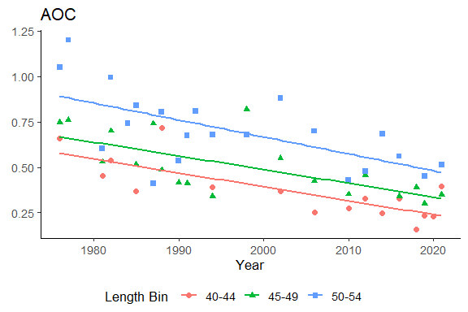

```r
print(trend_results$plot)
```

```r
interaction_fmt <- ifelse(is.na(trend_results$interaction_p), "NA",
                          ifelse(trend_results$interaction_p < 0.001, "< 0.001", signif(trend_results$interaction_p, 3)))

temporal_text <- {
  # Interaction explanation
  interaction_fmt <- ifelse(
    is.na(trend_results$interaction_p),
    "NA",
    ifelse(trend_results$interaction_p < 0.001, "< 0.001", signif(trend_results$interaction_p, 3))
  )

  interaction_line <- if (trend_results$interaction_sig) {
    top_bins_str <- str_sort(trend_results$top_bins, numeric = TRUE) %>%
  glue::glue_collapse(sep = ", ", last = " and ")
    glue::glue(
      "A linear model detected a significant interaction between year and fish length (p = {interaction_fmt}). ",
      "Trends were therefore assessed separately for the top 3 most sampled length bins: {bin_str} cm."
    )
  } else {
    glue::glue(
      "No significant interaction was detected between year and fish length (p = {interaction_fmt}). ",
      "Trends were assessed using mean contaminant concentrations per year."
    )
  }

  # R² summary
  r2_line <- if ("AOC" %in% trend_results$model_stats$region &&
                 nrow(trend_results$model_stats) == 1) {
    aoc_r2 <- trend_results$model_stats %>% filter(region == "AOC") %>% pull(r2)
    glue::glue("Overall model R² = {round(aoc_r2, 2)}.")
  } else {
    r2_str <- trend_results$model_stats %>%
      mutate(str = glue::glue("**{region}** = {round(r2, 2)}")) %>%
      pull(str) %>%
      glue::glue_collapse(sep = ", ")
    glue::glue("Overall model R² by region: {r2_str}.")
  }

  # Combine both parts
  glue::glue("{interaction_line} {r2_line}")
}
```

```r
if (trend_results$interaction_sig) {
  # ======= Interaction significant — summarize by bin =======
  tier3c_summary <- trend_results$trend_bins %>%
    filter(region == "AOC") %>%
    count(trend, name = "n") %>%
    mutate(trend = factor(trend, levels = c("Declining", "Stable", "Increasing"))) %>%
    arrange(trend)

  format_trend_phrase <- function(n, trend) {
    verb <- ifelse(n == 1, "was", "were")
    bin_word <- ifelse(n == 1, "bin", "bins")
    glue::glue("{n} {bin_word} {verb} {tolower(trend)}")
  }

  trend_sentences <- pmap_chr(
  list(n = tier3c_summary$n, trend = tier3c_summary$trend),
  format_trend_phrase
) %>%
  glue::glue_collapse(sep = ", ", last = ", and ")


  tier3c_result_text <- glue::glue(
    "In the AOC, {trend_sentences}. These trends were assessed using annual linear models by length bin."
  )

  tier3c_overall <- if (any(tier3c_summary$trend == "Increasing")) "Unsupportive" else "Supportive"

} else {
  # ======= No interaction — summarize overall slope =======
  aoc_slope <- trend_results$model_stats %>%
    filter(region == "AOC") %>%
    pull(slope)

  direction <- case_when(
    aoc_slope > 0 ~ "increasing",
    aoc_slope < 0 ~ "decreasing",
    TRUE ~ "stable"
  )

  tier3c_result_text <- glue::glue(
    "In the AOC, {contaminant_label} concentrations were {direction} over time. ",
    "This trend was assessed using an annual linear model of mean concentration."
  )

  tier3c_overall <- if (aoc_slope > 0) "Unsupportive" else "Supportive"
}


tier3c_metric_text <- if (trend_results$interaction_sig) {
  # Interaction model — summarize trend direction per bin
  trend_counts <- trend_results$trend_bins %>%
    filter(region == "AOC") %>%
    count(trend) %>%
    tidyr::complete(trend = c("Declining", "Stable", "Increasing"), fill = list(n = 0))

  glue::glue(
    "Significant length × year interaction (p = {interaction_fmt}); ",
    "{trend_counts$n[trend_counts$trend == 'Declining']} declining, ",
    "{trend_counts$n[trend_counts$trend == 'Stable']} stable, ",
    "{trend_counts$n[trend_counts$trend == 'Increasing']} increasing bins"
  )
} else {
  # No interaction — summarize slope direction
  aoc_slope <- trend_results$model_stats %>%
    filter(region == "AOC") %>%
    pull(slope)

  direction <- case_when(
    aoc_slope > 0 ~ "increasing",
    aoc_slope < 0 ~ "decreasing",
    TRUE ~ "stable"
  )

  glue::glue(
    "No significant interaction (p = {interaction_fmt}); ",
    "overall AOC trend: {direction}"
  )
}


tier3c_summary_tibble <- tibble(
  Tier = "Tier 3C",
  Description = "Temporal Trends",
  Metric = tier3c_metric_text,
  Outcome = tier3c_overall
)
```

```r
cat(temporal_text)
```

A linear model detected a significant interaction between year and fish length (p = < 0.001). Trends were therefore assessed separately for the top 3 most sampled length bins: 45-49, 40-44 and 50-54 cm. Overall model R² = 0.66.

```r
cat(tier3c_result_text)
```

In the AOC, 2 bins were declining, and 1 bin was stable. These trends were assessed using annual linear models by length bin.

**Tier 3C Overall Decision:** Supportive

## Tier 3D: Half-life

A half-life for Mercury concentrations in Walleye was predicted for the AOC and reference sites using a generalized additive mixed model (GAMM). The log values of Mercury concentration were estimated using year as a linear predictor by region, with smooth effects controlling for fish length. Sampling sites were used as random effects to account for repeated sampling. The slope (on log scale) represents the annual rate of change in Mercury concentration, defined as k = -slope.

```r
g_gamm <- gamm(
  log(Value) ~ Sample.Year + s(Length, k = 6) +Sample.Year*region,
  random = list(Waterbody.Code = ~ 1),
  data = filtered_data
)
# Extract linear coefficients for Year and Year:region to get region-specific k

t3d_gam = g_gamm$gam
t3d_lme = g_gamm$lme

# helper to get estimate/SE for a linear combo of coefficients
lc_est <- function(coefs, vc, pick) {
  # pick: named numeric vector whose names match coef names, values are weights
  a <- numeric(length(coefs)); names(a) <- names(coefs)
  a[names(pick)] <- pick
  est <- sum(a * coefs)
  se  <- sqrt(as.numeric(t(a) %*% vc %*% a))
  list(est = est, se = se)
}


co <- coef(t3d_gam)
vc <- vcov(t3d_gam)

# find all region levels
regs <- levels(filtered_data$region)


# build results per region
hl_tab <- map_dfr(regs, function(rg) {
  # slope on log scale for region rg
  # baseline: slope = coef["Sample.Year"]
  # non-baseline: slope = coef["year_c"] + coef[paste0("Sample.Year:region", rg)]
  pick <- c(`Sample.Year` = 1)
  int_name <- paste0("Sample.Year:region", rg)
  if (int_name %in% names(co)) pick[int_name] <- 1

  est <- lc_est(co, vc, pick)
  slope <- est$est
  slope_se <- est$se

  k <- -slope
  # delta-method SE for t1/2 = ln2 / k = ln2 / (-slope)
  # dt/dslope = ln2 / slope^2
  ln2 <- log(2)
  t12 <- ifelse(k > 0, ln2 / k, NA_real_)              # only for declining trends
  t2  <- ifelse(k <= 0, ln2 / abs(k), NA_real_)        # if increasing, report doubling time

  # SE via delta method
  dtds <- ln2 / (slope^2)
  t12_se <- ifelse(!is.na(t12), abs(dtds) * slope_se, NA_real_)
  t2_se  <- ifelse(!is.na(t2),  abs(dtds) * slope_se, NA_real_)

  tibble(
    region = rg,
    slope_log_per_year = slope,
    slope_se = slope_se,
    k = k,
    half_life_years = t12,
    half_life_lwr = ifelse(!is.na(t12), t12 - 1.96 * t12_se, NA_real_),
    half_life_upr = ifelse(!is.na(t12), t12 + 1.96 * t12_se, NA_real_),
    doubling_time_years = t2,
    doubling_lwr = ifelse(!is.na(t2), t2 - 1.96 * t2_se, NA_real_),
    doubling_upr = ifelse(!is.na(t2), t2 + 1.96 * t2_se, NA_real_)
  )
})
```

```r
library(mgcv)
library(dplyr)
library(glue)
library(knitr)
library(kableExtra)

# Round to nearest 5 cm
round5 <- function(x) round(x / 5) * 5

# AOC-only years-to-threshold with 95% CI and simplified outputs
compute_years_to_threshold_AOC <- function(
  t3d_gam, hl_tab, thresholds_df, restrict_threshold, filtered_data,
  aoc_level = "AOC"
) {
  # Ensure region levels match the model
  region_levels <- levels(model.frame(t3d_gam)$region)

  # Representative length (median, rounded to 5 cm)
  median_len <- round5(median(filtered_data$Length, na.rm = TRUE))

  # Baseline year for AOC (anchor to most recent observed)
  year_anchor <- filtered_data %>%
    filter(region == aoc_level) %>%
    summarise(year_anchor = max(Sample.Year, na.rm = TRUE), .groups = "drop") %>%
    pull(year_anchor)

  # Target concentration for the desired meals/month
  target_conc <- thresholds_df %>%
    filter(meals == restrict_threshold) %>%
    pull(conc)
  if (length(target_conc) == 0) stop("restrict_threshold not found in thresholds_df")

  # Predict baseline log-concentration for AOC at (median_len, year_anchor)
  newdata <- tibble(
    region = factor(aoc_level, levels = region_levels),
    Sample.Year = year_anchor,
    Length = median_len
  )
  pred <- predict(t3d_gam, newdata = newdata, type = "link", se.fit = TRUE)
  pred_log <- as.numeric(pred$fit)         # log(c0)
  se_log   <- as.numeric(pred$se.fit)      # SE on log-scale
  pred_c0  <- exp(pred_log)                # c0 (current predicted conc)

  # Grab k and slope SE for AOC
  krow <- hl_tab %>% filter(region == aoc_level)
  if (nrow(krow) != 1) stop("Could not find unique AOC row in hl_tab")
  k        <- krow$k[1]                    # = -slope
  slope_se <- krow$slope_se[1]             # SE of slope (same as SE of k)

  # Compute years to threshold and 95% CI (delta method)
  log_target <- log(target_conc)
  years_to_target <- dplyr::case_when(
    pred_c0 <= target_conc ~ 0,
    is.finite(k) & k > 0   ~ (pred_log - log_target) / k,
    TRUE                   ~ NA_real_
  )

  se_t <- if (is.finite(years_to_target) && !is.na(years_to_target) && k > 0) {
    # dt/d(log c0) = 1/k ; dt/dk = -(log(c0)-log(c*))/k^2 = -t/k
    term1 <- (1 / k)^2 * (se_log^2)
    term2 <- (years_to_target / k)^2 * (slope_se^2)
    sqrt(term1 + term2)
  } else {
    NA_real_
  }
  lwr <- if (is.na(se_t)) NA_real_ else years_to_target - 1.96 * se_t
  upr <- if (is.na(se_t)) NA_real_ else years_to_target + 1.96 * se_t

  # Outcome logic (AOC-only)
  outcome <- dplyr::case_when(
    !is.na(years_to_target) && years_to_target == 0 ~ "Supportive",
    is.na(years_to_target) | k <= 0                 ~ "Unsupportive",
    years_to_target > 10                             ~ "Unsupportive",
    TRUE                                             ~ "Supportive"
  )

  # ---- Simplified TIDY TABLE  ----
  results_tbl <- tibble(
    median_len_cm   = median_len,
    predicted_conc  = pred_c0,
    target_conc     = target_conc,
    years_to_target = years_to_target,
    years_lwr       = lwr,
    years_upr       = upr,
    outcome         = outcome
  )

  # ---- Pretty KABLE for reporting ----
  results_kable <- results_tbl %>%
    mutate(
      predicted_conc  = sprintf("%.2f", predicted_conc),
      target_conc     = sprintf("%.2f", target_conc),
      years_to_target = ifelse(is.na(years_to_target), "—", sprintf("%.1f", years_to_target)),
      ci_95 = dplyr::case_when(
        is.na(years_lwr) | is.na(years_upr) ~ "—",
        TRUE                                ~ sprintf("%.1f–%.1f", years_lwr, years_upr)
      )
    ) %>%
    select(
      `Median Length (cm)` = median_len_cm,
      `Predicted Conc`     = predicted_conc,
      `Target Conc`        = target_conc,
      `Years to Threshold` = years_to_target,
      `95% CI`             = ci_95,
      `Outcome`            = outcome
    ) %>%
    kable(
      format  = "html",
      caption = glue("Tier 3D (AOC): Time to reach an unrestrictive advisory of {restrict_threshold} meals/month for median-length fish")
    ) %>%
    kable_styling(full_width = FALSE, position = "center")

  # ---- Human-friendly METRIC TEXT (short, one-liner) ----
  metric_text <- dplyr::case_when(
    is.na(years_to_target) ~ glue("Trend does not indicate a decline; target not reachable under current trend."),
    years_to_target == 0   ~ glue("Already unrestrictive for median-length ({median_len} cm) fish."),
    TRUE                   ~ {
      if (!is.na(lwr) && !is.na(upr)) {
        glue("Approximately {round(years_to_target, 1)} years (95% CI {round(lwr, 1)}–{round(upr, 1)}) to reach an unrestrictive meal allowance for median-length ({median_len} cm) fish.")
      } else {
        glue("Approximately {round(years_to_target, 1)} years to reach an unrestrictive meal allowance for median-length ({median_len} cm) fish.")
      }
    }
  )

  # ---- REPORT TEXT ----

  report_text <- dplyr::case_when(
    is.na(years_to_target) ~ glue(
      "For median-length ({median_len} cm) fish, the current trend does not indicate declining {tolower(contaminant)} concentrations. ",
      "Under the present trend, reaching an unrestrictive monthly meal allowance of {restrict_threshold} meals/month for the Sensitive population is not expected."
    ),
    years_to_target == 0 ~ glue(
      "For median-length ({median_len} cm) fish, predicted concentrations are already within the unrestrictive advisory range for the Sensitive population (≥ {restrict_threshold} meals/month)."
    ),
    TRUE ~ {
      if (!is.na(lwr) && !is.na(upr)) {
        glue(
          "For median-length ({median_len} cm) fish, it is predicted to take about {round(years_to_target, 1)} years ",
          "(95% CI {round(lwr, 1)}–{round(upr, 1)}) to reach an unrestrictive monthly meal allowance of {restrict_threshold} meals/month for the Sensitive population."
        )
      } else {
        glue(
          "For median-length ({median_len} cm) fish, it is predicted to take about {round(years_to_target, 1)} years ",
          "to reach an unrestrictive monthly meal allowance of {restrict_threshold} meals/month for the Sensitive population."
        )
      }
    }
  )

  # Outcome string for your tier summary row
  tier3d_overall <- outcome

  # Tier 3D summary tibble (mirrors your Tier 3A/3B pattern)
  tier3d_summary_tibble <- tibble(
    Tier = "Tier 3D",
    Description = "Half-life / Time to Unrestrictive Advisory (AOC)",
    Metric = metric_text,
    Outcome = tier3d_overall
  )

  list(
    results_tbl           = results_tbl,     # programmatic table (simplified)
    results_kable         = results_kable,   # report table
    metric_text           = metric_text,     # short one-liner
    report_text           = report_text,     # longer prose (tier-style)
    tier3d_summary_tibble = tier3d_summary_tibble
  )
}
```

```r
aoc_out <- compute_years_to_threshold_AOC(
  t3d_gam, hl_tab, thresholds_df, params$restrict_threshold, filtered_data,
  aoc_level = "AOC" # adjust if your AOC factor level differs
)
```

[output not shown]

```r
aoc_out$results_kable
```

[output not shown]

Tier 3D (AOC): Time to reach an unrestrictive advisory of 8 meals/month for median-length fish

| Median Length (cm) | Predicted Conc | Target Conc | Years to Threshold | 95% CI | Outcome |
| --- | --- | --- | --- | --- | --- |
| 50 | 0.38 | 0.16 | 57.0 | 32.4–81.7 | Unsupportive |

A model test was performed to estimate the time required to reach a nonrestrictive monthly meal allowance for the median fish length (rounded to the nearest 5 cm) for sensitive populations. A timeline of 10 years or fewer is considered supportive of delisting, whereas a timeline of 10 or more years is unsupportive.

# Final summary

```r
tier3_summary_table <- bind_rows(
  tier3a_summary_tibble,
  tier3b_summary_tibble,
  tier3c_summary_tibble,
  aoc_out$tier3d_summary_tibble,
)

knitr::kable(tier3_summary_table, caption = "Summary of Tier 3 Evidence Lines and Outcomes")
```

[output not shown]

Summary of Tier 3 Evidence Lines and Outcomes

| Tier | Description | Metric | Outcome |
| --- | --- | --- | --- |
| Tier 3A | Virtual Advisory | General: 3/13 size bins restrictive or more restrictive than reference; Sensitive: 6/13 size bins restrictive or more restrictive than reference | Unsupportive |
| Tier 3B | Contaminant Concentration vs Reference | Significantly different smooth terms (p = 0.0492531); 11/11 lengths with higher AOC concentration | Unsupportive |
| Tier 3C | Temporal Trends | Significant length × year interaction (p = < 0.001); 2 declining, 1 stable, 0 increasing bins | Supportive |
| Tier 3D | Half-life / Time to Unrestrictive Advisory (AOC) | Approximately 57 years (95% CI 32.4–81.7) to reach an unrestrictive meal allowance for median-length (50 cm) fish. | Unsupportive |